# 4.2 - Árbol de decisión para el triaje de urgencias

De todos los algoritmos que estudia el equipo de Minermont en AIA, el **árbol de decisión** es el que más entusiasma a Teresa, la enfermera jefe de triaje: "Realmente se parece a cómo pensamos en triaje". Un árbol hace una pregunta cada vez sobre el paciente, como en el juego *¿Quién es quién?*:

- El **nodo raíz** contiene a todos los pacientes.
- Cada **nodo interno** hace una pregunta sobre una característica ("¿dolor torácico?", "¿edad ≤ 44,5?").
- Cada **hoja** da el nivel predicho.

En este cuaderno:

1. Importar las bibliotecas.
2. Los datos de triaje.
3. Cómo elige el árbol cada pregunta: la impureza y la mejor división, a mano.
4. Un árbol sin límites: el sobreajuste.
5. Elegir la profundidad con validación cruzada.
6. Leer el árbol.
7. Dos debilidades: umbrales rígidos e inestabilidad.
8. Evaluación final.

### Paso 1: Importar las bibliotecas

Los árboles comparan cada característica con un umbral, así que, a diferencia de KNN, no necesitan que las características estén escaladas.

```python
import numpy as np
import pandas as pd
import matplotlib.pyplot as plt
from sklearn.model_selection import train_test_split, StratifiedKFold, cross_validate
from sklearn.tree import DecisionTreeClassifier, plot_tree, export_text
from sklearn.metrics import classification_report, ConfusionMatrixDisplay
```

### Paso 2: Los datos de triaje

Los registros de urgencias de un hospital real son confidenciales, así que generamos **pacientes sintéticos** que se comportan como los del libro. La siguiente celda contiene el generador. No hace falta seguirlo línea a línea: lo importante es que el nivel de urgencia sale de un protocolo oculto (una puntuación de alerta temprana basada en los signos vitales, más algunas señales de alarma clínicas) y del criterio de la propia enfermera, que a veces mueve el nivel un escalón. Los modelos nunca ven esa regla: tienen que descubrirla a partir de los ejemplos.

| Columna | Significado |
| --- | --- |
| `edad` | Edad en años (1–97; aproximadamente uno de cada ocho pacientes es un niño) |
| `hombre` | 1 si el paciente es hombre, 0 si es mujer |
| `presion_sistolica` | Presión arterial sistólica (mmHg) |
| `frec_cardiaca` | Frecuencia cardiaca (latidos por minuto) |
| `frec_respiratoria` | Frecuencia respiratoria (respiraciones por minuto) |
| `spo2` | Saturación de oxígeno (%) |
| `temperatura` | Temperatura (°C) |
| `consciencia` | Nivel de consciencia: 0 alerta, 1 responde a la voz, 2 responde solo al dolor, 3 no responde |
| `dolor` | Dolor referido por el paciente (0–10) |
| `dolor_toracico`, `disnea`, `traumatismo`, `vomitos` | Síntomas de consulta: dolor torácico, dificultad para respirar, traumatismo, vómitos (1 = sí) |
| `nivel` | **Objetivo**: nivel de urgencia, de 1 (rojo, inmediato) a 5 (azul, no urgente) |

```python
def generate_patients(n, seed):
    """Pacientes sintéticos de urgencias de Minermont: una fila por paciente, con el nivel de urgencia asignado en el triaje."""
    rng = np.random.default_rng(seed)
    age = np.clip(np.round(np.where(rng.random(n) < 0.12, rng.uniform(1, 17, n), rng.normal(52, 20, n))), 1, 97)
    male = rng.binomial(1, 0.5, n)
    s = rng.gamma(0.9, 0.55, n)                        # gravedad oculta del episodio (el modelo nunca la ve)
    infection = rng.binomial(1, 0.12 + 0.1 * (s > 1), n)
    trauma = rng.binomial(1, 0.2, n)
    chest_pain = rng.binomial(1, np.clip(0.04 + 0.0025 * age, 0, 0.35), n)
    dyspnea = rng.binomial(1, np.clip(0.06 + 0.25 * s, 0, 0.9), n)
    vomiting = rng.binomial(1, 0.12, n)
    shock = (rng.random(n) < 0.35) & (s > 1.2)
    hr = 76 + 16 * s + 12 * infection + rng.normal(0, 10, n)
    brady = (rng.random(n) < 0.08) & (s > 1.3)         # algunos pacientes graves tienen el pulso muy lento
    hr = np.where(brady, rng.normal(42, 6, n), hr)
    rr = 15 + 4.5 * s + 3 * dyspnea + rng.normal(0, 2.2, n)
    spo2 = np.clip(98.2 - 2.2 * s * (0.5 + dyspnea) + rng.normal(0, 1.1, n), 70, 100)
    sbp = np.clip(128 + 0.25 * (age - 50) + rng.normal(0, 16, n) - 28 * s * shock, 60, 230)
    temp = 36.8 + rng.normal(0, 0.35, n) + infection * rng.normal(1.6, 0.6, n)
    p_consc = np.clip(0.02 * s ** 2.2, 0, 0.9)
    consc = np.where(rng.random(n) < p_consc, rng.choice([1, 2, 3], n, p=[0.55, 0.3, 0.15]), 0)
    pain = np.clip(np.round(rng.normal(2.5 + 3.5 * trauma + 3 * chest_pain + 0.8 * s, 1.8, n)), 0, 10).astype(int)
    hr, rr, sbp = np.round(hr).astype(int), np.round(rr).astype(int), np.round(sbp).astype(int)
    temp, spo2 = np.round(temp, 1), np.round(spo2).astype(int)

    # El protocolo oculto detrás de las etiquetas, que solo usamos para generar los datos:
    # una puntuación de alerta temprana en la que un signo vital suma puntos si es demasiado bajo O demasiado alto...
    score = (np.select([rr <= 8, rr <= 11, rr <= 20, rr <= 24], [3, 1, 0, 2], 3)
             + np.select([spo2 <= 91, spo2 <= 93, spo2 <= 95], [3, 2, 1], 0)
             + np.select([sbp <= 90, sbp <= 100, sbp <= 110, sbp <= 219], [3, 2, 1, 0], 3)
             + np.select([hr <= 40, hr <= 50, hr <= 90, hr <= 110, hr <= 130], [3, 1, 0, 1, 2], 3)
             + np.where(consc > 0, 3, 0)
             + np.select([temp <= 35, temp <= 36, temp <= 38, temp <= 39], [3, 1, 0, 1], 2))
    # ...más discriminadores clínicos, del nivel menos urgente al más urgente
    level = np.full(n, 5)
    level = np.where((score >= 1) | (pain >= 4) | (trauma == 1), 4, level)
    level = np.where((score >= 4) | (pain >= 7) | (temp >= 39) | ((chest_pain == 1) & (age < 45)), 3, level)
    level = np.where((score >= 6) | ((chest_pain == 1) & (age >= 45)) | (spo2 <= 91), 2, level)
    level = np.where((score >= 9) | (consc >= 2) | (sbp <= 80), 1, level)
    # y el criterio de la propia enfermera, que a veces mueve el nivel un escalón
    level = np.clip(level + rng.choice([-1, 0, 1], n, p=[0.05, 0.9, 0.05]), 1, 5)

    return pd.DataFrame({
        'edad': age.astype(int), 'hombre': male, 'presion_sistolica': sbp, 'frec_cardiaca': hr, 'frec_respiratoria': rr,
        'spo2': spo2, 'temperatura': temp, 'consciencia': consc, 'dolor': pain, 'dolor_toracico': chest_pain,
        'disnea': dyspnea, 'traumatismo': trauma, 'vomitos': vomiting, 'nivel': level,
    })
```

```python
df = generate_patients(4000, seed=42)
feature_names = [c for c in df.columns if c != 'nivel']
level_names = ['1 Rojo', '2 Naranja', '3 Amarillo', '4 Verde', '5 Azul']
X = df[feature_names]
y = df['nivel']

X_train, X_test, y_train, y_test = train_test_split(X, y, test_size=0.25, random_state=42, stratify=y)
print(f"Entrenamiento: {len(y_train)} pacientes, prueba: {len(y_test)} pacientes\n")
print("Pacientes por nivel de urgencia:")
print(pd.DataFrame({'pacientes': y.value_counts().sort_index(),
                    'proporción': y.value_counts(normalize=True).sort_index().round(3)},).set_axis(level_names).to_string())
```

```
Entrenamiento: 3000 pacientes, prueba: 1000 pacientes

Pacientes por nivel de urgencia:
            pacientes  proporción
1 Rojo            158       0.040
2 Naranja         530       0.132
3 Amarillo        780       0.195
4 Verde          1671       0.418
5 Azul            861       0.215
```

### Paso 3: Cómo elige el árbol cada pregunta

El libro describe la construcción como "divide y vencerás": en cada nodo, buscar la característica y el punto de corte que dividen a los pacientes en grupos **lo más puros posible**, es decir, en los que la mayoría de los pacientes tienen el mismo nivel. La pureza se mide con la **impureza de Gini** de un grupo, donde $p_k$ es la proporción de pacientes de nivel $k$:

$$G = 1 - \sum_{k=1}^{5} p_k^2$$

$G = 0$ si todos los pacientes tienen el mismo nivel, y crece cuando los niveles están mezclados. La calidad de una división es la impureza de Gini de los dos grupos resultantes, ponderada por su tamaño. Buscamos la mejor primera pregunta probando todas las características y todos los umbrales, a medio camino entre dos valores consecutivos:

```python
def gini(levels):
    p = np.bincount(levels, minlength=6)[1:] / len(levels)
    return 1 - np.sum(p ** 2)

y_arr = y_train.to_numpy()
print(f"Impureza de Gini de la raíz (todos los pacientes de entrenamiento): {gini(y_arr):.3f}\n")

best = {'impurity': np.inf}
for col in feature_names:
    x = X_train[col].to_numpy()
    values = np.unique(x)
    for threshold in (values[:-1] + values[1:]) / 2:
        left, right = y_arr[x <= threshold], y_arr[x > threshold]
        weighted = (len(left) * gini(left) + len(right) * gini(right)) / len(y_arr)
        if weighted < best['impurity']:
            best = {'impurity': weighted, 'feature': col, 'threshold': threshold}
print(f"Mejor primera pregunta: {best['feature']} <= {best['threshold']}  "
      f"(impureza ponderada {best['impurity']:.3f})")

stump = DecisionTreeClassifier(max_depth=1).fit(X_train, y_train)
print(f"Raíz de scikit-learn:   {feature_names[stump.tree_.feature[0]]} <= {stump.tree_.threshold[0]}")
```

```
Impureza de Gini de la raíz (todos los pacientes de entrenamiento): 0.722

Mejor primera pregunta: dolor_toracico <= 0.5  (impureza ponderada 0.633)
Raíz de scikit-learn:   dolor_toracico <= 0.5
```

Nuestra búsqueda encuentra la misma primera pregunta que scikit-learn: **¿tiene el paciente dolor torácico?** Baja la impureza de 0,722 a 0,633, más que cualquier otra característica o umbral. Después el árbol repite la misma búsqueda dentro de cada uno de los dos grupos, y así sucesivamente.

### Paso 4: Un árbol sin límites

La construcción se repite en cada nodo hijo hasta que las hojas son puras. ¿Qué pasa si no la detenemos?

```python
full_tree = DecisionTreeClassifier(random_state=0).fit(X_train, y_train)
print(f"Profundidad: {full_tree.get_depth()}, hojas: {full_tree.get_n_leaves()}")
print(f"Exactitud en entrenamiento: {full_tree.score(X_train, y_train):.3f}")
print(f"Exactitud en prueba:        {full_tree.score(X_test, y_test):.3f}")
```

```
Profundidad: 25, hojas: 545
Exactitud en entrenamiento: 1.000
Exactitud en prueba:        0.730
```

Una puntuación perfecta en entrenamiento y 0,730 con pacientes nuevos. Con 25 niveles de preguntas y 545 hojas, muchas hojas contienen solo uno o dos pacientes: el árbol ha memorizado los datos de entrenamiento, incluidos los casos en los que el criterio de la enfermera movió el nivel. Es lo que Alma le enseña al equipo en el libro: un 100% de exactitud con los datos con los que se entrenó y resultados mucho peores con datos nuevos.

### Paso 5: Elegir la profundidad

La forma más sencilla de controlar un árbol es limitar su **profundidad máxima**, el número de preguntas desde la raíz hasta una hoja. La elegimos con validación cruzada estratificada de 5 grupos sobre el conjunto de entrenamiento, y registramos también la exactitud de entrenamiento para ver la distancia entre las dos:

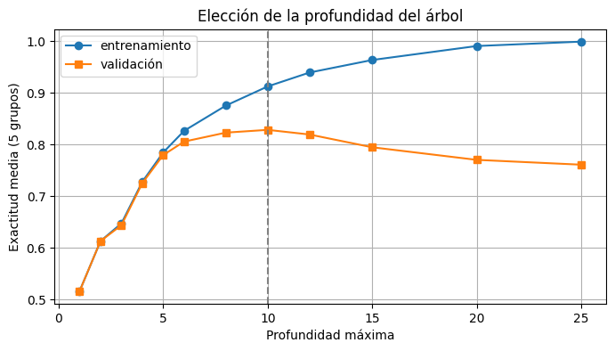

```
profundidad 1: 0.516  profundidad 2: 0.613  profundidad 3: 0.644  profundidad 4: 0.725  profundidad 5: 0.779  profundidad 6: 0.805  profundidad 8: 0.823  profundidad 10: 0.828  profundidad 12: 0.819  profundidad 15: 0.794  profundidad 20: 0.770  profundidad 25: 0.761
Mejor profundidad: 10
```

```python
cv = StratifiedKFold(n_splits=5, shuffle=True, random_state=42)
depths = [1, 2, 3, 4, 5, 6, 8, 10, 12, 15, 20, 25]
train_scores, val_scores = [], []
for d in depths:
    scores = cross_validate(DecisionTreeClassifier(max_depth=d, random_state=0), X_train, y_train, cv=cv, return_train_score=True)
    train_scores.append(scores['train_score'].mean())
    val_scores.append(scores['test_score'].mean())
best_depth = depths[int(np.argmax(val_scores))]

plt.figure(figsize=(8, 4))
plt.plot(depths, train_scores, 'o-', label='entrenamiento')
plt.plot(depths, val_scores, 's-', label='validación')
plt.axvline(best_depth, color='gray', linestyle='--')
plt.xlabel('Profundidad máxima')
plt.ylabel('Exactitud media (5 grupos)')
plt.title('Elección de la profundidad del árbol')
plt.legend()
plt.grid(True)
plt.show()
print("  ".join(f"profundidad {d}: {v:.3f}" for d, v in zip(depths, val_scores)))
print(f"Mejor profundidad: {best_depth}")
```

Con pocas preguntas el árbol es demasiado simple (subajuste). A partir de la profundidad 10 la exactitud de entrenamiento sigue subiendo mientras la de validación baja (sobreajuste). La mejor profundidad es 10, con una exactitud media de validación de 0,828, claramente mejor que dejar crecer el árbol hasta su profundidad completa de 25 (0,761).

### Paso 6: Leer el árbol

Un árbol de profundidad 10 ya es demasiado grande para leerlo. Para ver su lógica, dibujemos un árbol de **profundidad 3**: solo tres preguntas desde la raíz hasta cada hoja.

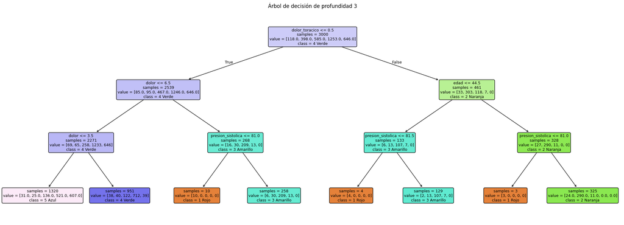

```
|--- dolor_toracico <= 0.50
|   |--- dolor <= 6.50
|   |   |--- dolor <= 3.50
|   |   |   |--- class: 5 Azul
|   |   |--- dolor >  3.50
|   |   |   |--- class: 4 Verde
|   |--- dolor >  6.50
|   |   |--- presion_sistolica <= 81.00
|   |   |   |--- class: 1 Rojo
|   |   |--- presion_sistolica >  81.00
|   |   |   |--- class: 3 Amarillo
|--- dolor_toracico >  0.50
|   |--- edad <= 44.50
|   |   |--- presion_sistolica <= 81.50
|   |   |   |--- class: 1 Rojo
|   |   |--- presion_sistolica >  81.50
|   |   |   |--- class: 3 Amarillo
|   |--- edad >  44.50
|   |   |--- presion_sistolica <= 81.00
|   |   |   |--- class: 1 Rojo
|   |   |--- presion_sistolica >  81.00
|   |   |   |--- class: 2 Naranja

Exactitud en prueba del árbol de profundidad 3: 0.641
```

```python
small_tree = DecisionTreeClassifier(max_depth=3, random_state=0).fit(X_train, y_train)
plt.figure(figsize=(26, 9))
plot_tree(small_tree, feature_names=feature_names, class_names=level_names, filled=True, rounded=True,
          impurity=False, fontsize=9)
plt.title('Árbol de decisión de profundidad 3')
plt.show()
print(export_text(small_tree, feature_names=feature_names, class_names=level_names))
print(f"Exactitud en prueba del árbol de profundidad 3: {small_tree.score(X_test, y_test):.3f}")
```

### Paso 7: Dos debilidades

**Umbrales rígidos.** Marta señala en el libro que, si la mejor división de la edad es 65,1 años, alguien de 65 queda al otro lado. Nuestro árbol ha aprendido un umbral de 44,5 años para los pacientes con dolor torácico. Comparemos dos pacientes idénticos salvo por un año de edad:

```python
tree = DecisionTreeClassifier(max_depth=best_depth, random_state=0).fit(X_train, y_train)
patient = {'edad': 44, 'hombre': 1, 'presion_sistolica': 135, 'frec_cardiaca': 88, 'frec_respiratoria': 17, 'spo2': 97, 'temperatura': 36.8,
           'consciencia': 0, 'dolor': 6, 'dolor_toracico': 1, 'disnea': 0, 'traumatismo': 0, 'vomitos': 0}
two = pd.DataFrame([patient, {**patient, 'edad': 45}])
for age, level in zip(two['edad'], tree.predict(two)):
    print(f"Paciente de {age} años con dolor torácico -> {level_names[level - 1]}")
```

```
Paciente de 44 años con dolor torácico -> 3 Amarillo
Paciente de 45 años con dolor torácico -> 2 Naranja
```

Un año de edad cambia el nivel de amarillo a naranja. Aquí el umbral no es casualidad: el protocolo oculto que generó los datos usa 45 años para el dolor torácico, y el árbol lo ha encontrado. En los datos reales, sin embargo, el riesgo suele crecer poco a poco con la edad, y un umbral brusco trata a una persona de 44 años y a otra de 45 como pacientes completamente distintos.

**Inestabilidad.** Alma advierte al equipo de que un pequeño cambio en los datos puede producir un árbol muy distinto. Entrenamos árboles con dos muestras aleatorias del 90% de los pacientes de entrenamiento, que comparten la mayoría de sus pacientes, y contamos cuántos pacientes de prueba reciben un nivel distinto:

```python
samples = [np.random.default_rng(seed).choice(len(X_train), int(0.9 * len(X_train)), replace=False) for seed in (0, 1)]
for d, name in [(None, 'sin límites'), (best_depth, f'profundidad {best_depth}')]:
    trees = [DecisionTreeClassifier(max_depth=d, random_state=0).fit(X_train.iloc[s], y_train.iloc[s]) for s in samples]
    p1, p2 = trees[0].predict(X_test), trees[1].predict(X_test)
    print(f"Árboles {name:<15} hojas {trees[0].get_n_leaves()} y {trees[1].get_n_leaves()}: "
          f"nivel distinto para el {np.mean(p1 != p2):.1%} de los pacientes de prueba")
```

```
Árboles sin límites     hojas 494 y 485: nivel distinto para el 18.1% de los pacientes de prueba
Árboles profundidad 10  hojas 155 y 152: nivel distinto para el 7.0% de los pacientes de prueba
```

Dos árboles entrenados con casi los mismos pacientes dan un nivel distinto al 18,1% de los pacientes de prueba cuando crecen sin límites, y todavía al 7,0% con profundidad 10. Un bosque aleatorio convierte esta debilidad en una virtud: entrena cientos de árboles distintos y los deja votar.

### Paso 8: Evaluación final

Evaluamos, una sola vez, el árbol con la profundidad elegida por validación cruzada:

```
              precision    recall  f1-score   support

      1 Rojo      0.667     0.550     0.603        40
   2 Naranja      0.761     0.773     0.767       132
  3 Amarillo      0.736     0.744     0.740       195
     4 Verde      0.859     0.902     0.880       418
      5 Azul      0.919     0.842     0.879       215

    accuracy                          0.827      1000
   macro avg      0.788     0.762     0.774      1000
weighted avg      0.827     0.827     0.826      1000
```

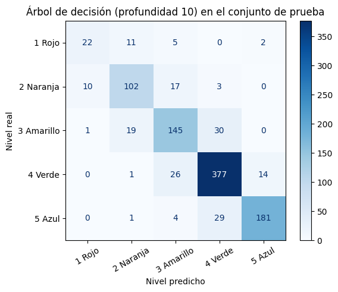

```python
y_pred = tree.predict(X_test)
print(classification_report(y_test, y_pred, target_names=level_names, digits=3))
ConfusionMatrixDisplay.from_predictions(y_test, y_pred, display_labels=level_names, cmap='Blues', xticks_rotation=30)
plt.xlabel('Nivel predicho')
plt.ylabel('Nivel real')
plt.title(f'Árbol de decisión (profundidad {best_depth}) en el conjunto de prueba')
plt.show()
```

El árbol de profundidad 10 alcanza 0,827 en el conjunto de prueba, mejor que KNN y que Naive Bayes, pero todavía encuentra solo a 22 de los 40 pacientes de nivel 1 (recall de 0,550).

### Conclusión

- Un árbol de decisión hace una pregunta cada vez, eligiendo en cada nodo la división que deja los grupos **más puros** (menor impureza de Gini). La búsqueda es voraz: escoge la mejor pregunta ahora, sin mirar hacia delante.
- Maneja características numéricas y categóricas sin escalado, capta interacciones (aquí la edad solo importa cuando hay dolor torácico) y un árbol pequeño puede ser **leído y revisado por los clínicos**.
- Sin límites **memoriza** los datos de entrenamiento. Hay que controlar su profundidad y elegirla con validación cruzada.
- Sus umbrales son **rígidos**, y pequeños cambios en los datos producen árboles distintos: es **inestable**. En el libro, Alma presenta los bosques aleatorios precisamente para resolver el sobreajuste y la inestabilidad. Son el tema del siguiente cuaderno.